# Projet Big Data - Patrimoine arbore de Saint-Quentin

Fonctionnalites 1 & 2 : exploration, nettoyage, visualisation

Elie & Clément & Victor

24/04/2026

# 1 Presentation du jeu de donnees

Le jeu de donnees recense les arbres de la ville de Saint-Quentin (Aisne). Il contient **11421 lignes** et **37 colonnes**. On peut regrouper les variables en quatre familles :

- geographiques : `X`, `Y` (coordonnees Lambert-93), `clc_quartier`, `clc_secteur` ;
- descriptives de l’arbre : `nomfrancais`, `nomlatin`, `feuillage`, `remarquable`, `fk_stadedev`, `fk_port`, `fk_pied`, `fk_situation`, `fk_revetement` ;
- metriques : `haut_tot`, `haut_tronc`, `tronc_diam`, `age_estim` ;
- etat/historique : `fk_arb_etat`, `dte_plantation`, `dte_abattage`, `clc_nbr_diag`.

Le reste (`OBJECTID`, `GlobalID`, `created_*`, `last_edited_*`, `Creator`…) est de la metadonnee de saisie, peu utile pour l’analyse.

# 2 Statistiques descriptives

## 2.1 Univariees

### 2.1.1 Variables numeriques

Resume des variables numeriques (apres nettoyage).

| variable | min | mediane | moyenne | max | NA_ |
| --- | --- | --- | --- | --- | --- |
| haut_tot | 1.0 | 8.0 | 10.4 | 37 | 170 |
| haut_tronc | 0.5 | 2.2 | 2.9 | 16 | 1098 |
| tronc_diam | 3.0 | 90.0 | 95.6 | 395 | 191 |
| age_estim | 1.0 | 30.0 | 31.5 | 200 | 1020 |

### 2.1.2 Variables categorielles

La grande majorite des arbres est encore **en place**, et seuls quelques arbres sont classes comme remarquables. On a surtout des feuillus (environ 86%), et les quartiers qui en concentrent le plus sont Saint-Martin - Oestres, Remicourt et le Faubourg d’Isle.

## 2.2 Bivariees

Moyennes des metriques par stade de developpement.

| Stade | n | Hauteur moy. | Diametre moy. | Age moy. |
| --- | --- | --- | --- | --- |
| adulte | 6475 | 12.8 | 124.9 | 41.2 |
| jeune | 4620 | 6.7 | 52.2 | 13.3 |
| vieux | 68 | 23.5 | 198.6 | 63.1 |
| senescent | 53 | 22.7 | 204.7 | 98.9 |

On voit que les moyennes grimpent bien quand on passe du stade jeune au stade vieux, ce qui est plutot rassurant : les variables mesurees sont coherentes entre elles.

# 3 Nettoyage des donnees

## 3.1 Problemes identifies pendant l’exploration

L’exploration (script `01_exploration.R`) a mis en evidence :

- des modalites categorielles saisies de facon incoherente : “Jeune” vs “jeune”, “Libre” vs “libre”, “Bande de terre” vs “bande de terre”… ;
- la chaine **“RAS”** utilisee comme valeur manquante dans plusieurs champs (commentaires, noms) ;
- des **zeros suspects** : 158 haut_tot, 159 tronc_diam, 168 age_estim. Un arbre vivant n’a pas une hauteur ou un diametre nul ;
- une valeur `age_estim = 2010` (saisie d’une annee a la place de l’age) ;
- 2 arbres sans coordonnees geographiques ;
- 74 doublons sur (X, Y, nom latin) - pas des doublons d’identifiant mais probablement des arbres **replantes** au meme endroit ;
- des dates de plantation a **1970-01-01** (epoch Unix : valeur par defaut).

## 3.2 Regles appliquees

A partir de ces constats, voici ce qu’on a decide :

- **Uniformiser les modalites texte** : tout passer en minuscules sans accents, pour que “Jeune” et “jeune” soient comptes comme la meme chose. On fait quand meme une exception pour les noms d’especes (`nomfrancais` et `nomlatin`) : on garde la casse et les accents d’origine. Sinon on se retrouverait avec “erable” au lieu de “Erable” sur les graphiques, et surtout “acer platanoides” au lieu de “Acer platanoides” alors que la convention en biologie est de mettre une majuscule au genre. Pour ces deux colonnes on se contente d’enlever les espaces en trop et de remplacer les “RAS” par NA.
- **Remplacer “RAS” et les cases vides par NA**, parce que c’est ce qu’elles sont vraiment.
- **Transformer les 0 sur hauteur / diametre / age en NA** : un arbre ne peut pas mesurer 0 m.
- **Traiter les valeurs trop grandes comme des erreurs de saisie** : age > 200 ans (sans doute une annee tapee par erreur), diametre > 4 m (pas credible), ou hauteur de tronc superieure a la hauteur totale (impossible).
- **Traiter les dates 1970-01-01 comme des NA**, c’est juste la valeur par defaut de la base quand la date n’a pas ete renseignee.
- **Supprimer les lignes sans coordonnees** : elles ne servent pas pour la carte.
- **Garder les “doublons” (X, Y, espece)** : ce sont probablement des arbres replantes au meme endroit, donc des informations legitimes.

Au final, apres nettoyage il nous reste **11419 lignes**, soit seulement 2 lignes en moins par rapport au fichier brut. L’annee de reference qu’on utilise pour calculer l’age (`age_calc`) est **2020**, c’est la date la plus recente qu’on voit dans les donnees.

## 3.3 Et les NA qui restent ?

Apres nettoyage, il reste encore des NA. On s’est demande si ca valait la peine de les remplacer par la mediane d’un groupe (par exemple, remplacer une hauteur manquante par la hauteur mediane des arbres de la meme espece).

Pour voir si un groupe est “pertinent” pour imputer, on a regarde combien de la variation d’une variable est expliquee par le groupe (c’est l’idee du R2 : plus il est proche de 1, plus le groupe contient l’info). Les meilleurs resultats qu’on obtient :

- hauteur totale par espece : R2 = 0.50
- diametre du tronc par stade : R2 = 0.44
- age estime par stade : R2 = 0.51
- hauteur de tronc par espece : R2 = 0.22

Au final on a prefere **ne pas imputer**, pour plusieurs raisons :

- l’age estime, c’est ce qu’on veut predire plus loin (fonctionnalite 5), donc si on le remplit nous-memes on va fausser l’evaluation du modele ;
- pour la hauteur totale et le diametre, il y a tres peu de NA (~1.5%), donc ca ne changerait pas grand chose ;
- pour la hauteur de tronc, le R2 est trop faible (0.22), le groupe n’est pas assez informatif : la mediane serait presque tiree au hasard ;
- pour la date de plantation, 86% sont manquantes - la ville ne la connait tout simplement pas, on ne peut rien inventer.

De toute facon, R gere tres bien les NA tout seul (`na.rm = TRUE` dans les fonctions, `ggplot` les ignore automatiquement). Le fichier final est exporte dans `data/clean/arbres_clean.csv`.

# 4 Visualisations

## 4.1 Repartition par stade de developpement

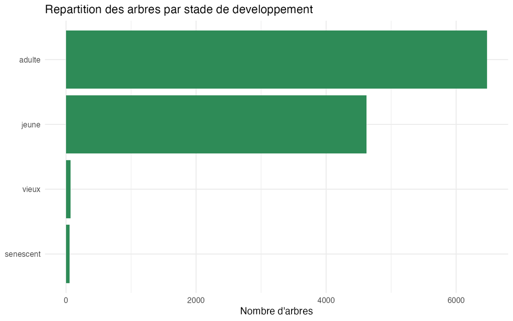

Repartition des arbres par stade de developpement.

## 4.2 Repartition geographique

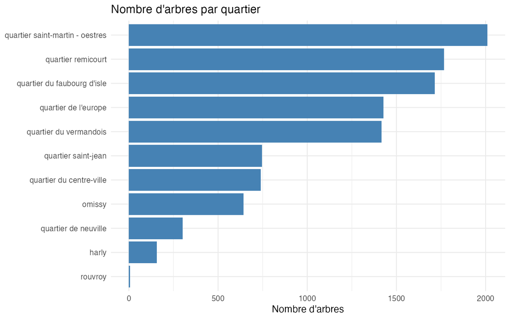

Nombre d’arbres par quartier.

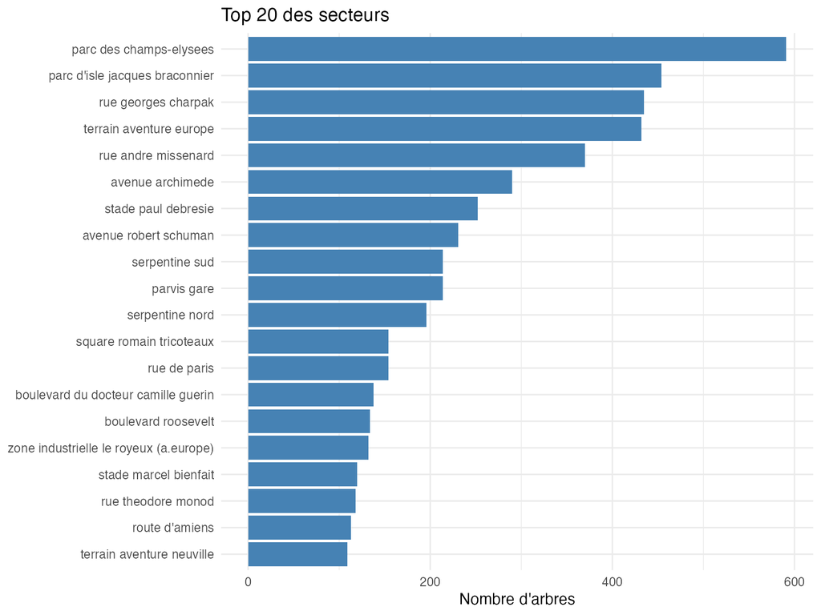

Top 20 des secteurs (rues / avenues).

## 4.3 Distributions des metriques

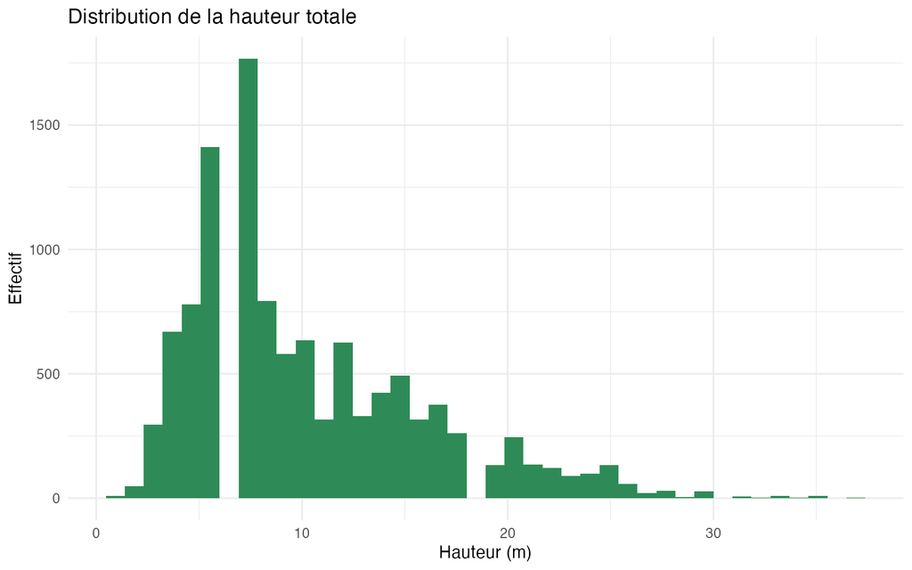

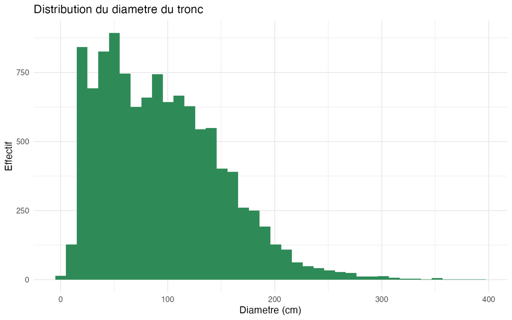

Distributions de la hauteur totale (gauche) et du diametre du tronc (droite).

Les deux histogrammes sont decales vers la gauche : on a beaucoup d’arbres petits ou moyens, et quelques gros qui tirent la queue de la distribution vers la droite. Concretement, la plupart des arbres mesurent entre 3 et 15 m de haut, avec un diametre de tronc entre 30 et 150 cm.

## 4.4 Croisements

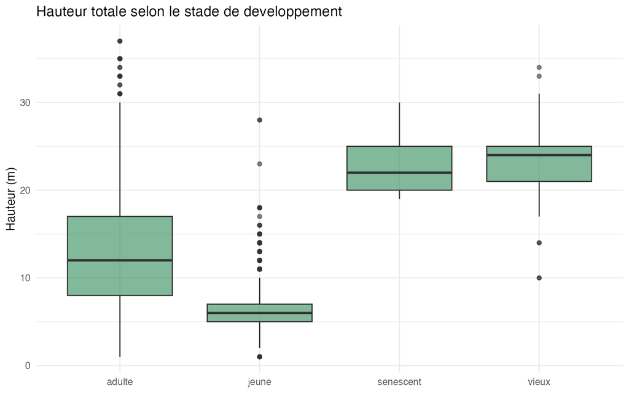

Hauteur totale selon le stade de developpement.

On voit clairement que la hauteur monte quand on passe de jeune a adulte puis a vieux / senescent. Ceci dit les boites sont assez larges (il y a beaucoup de variabilite a l’interieur de chaque stade), ce qui explique qu’on n’arrive pas a depasser un R2 de 0.3-0.5 quand on essaie de predire la hauteur a partir du stade.

## 4.5 Especes

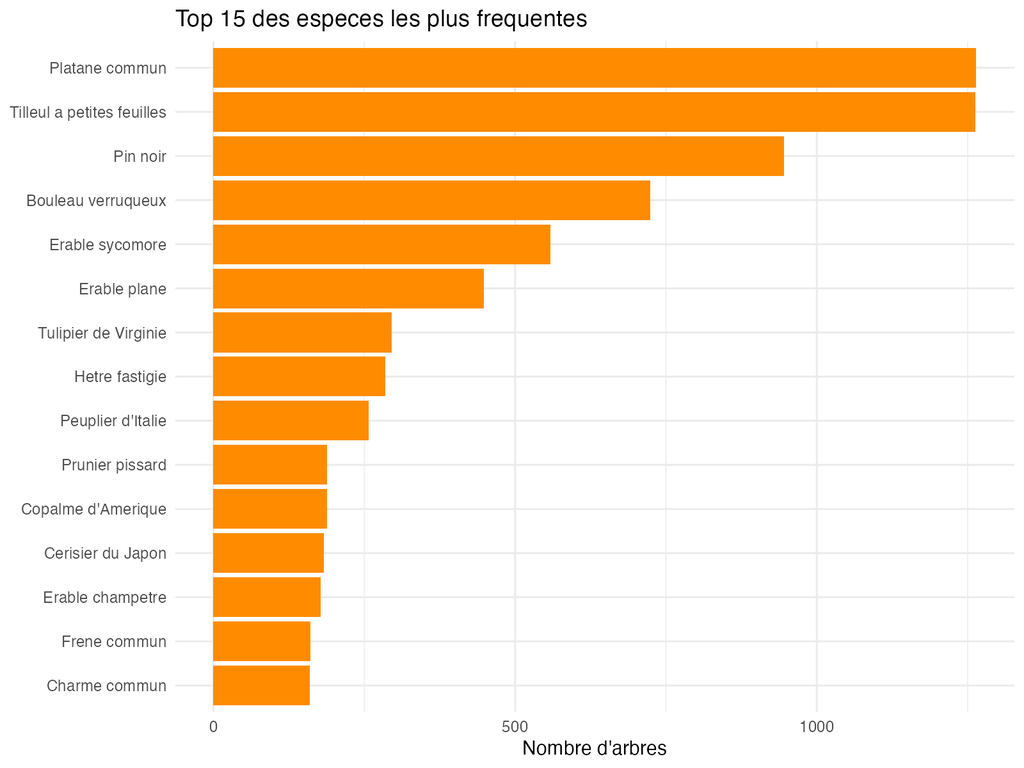

Top 15 des especes (nom francais).

Petite surprise en regardant les donnees de plus pres : la colonne `nomfrancais` du fichier brut ne contient pas de vrais noms francais, mais des codes courts (par exemple `PLAACE` pour le platane commun, `TILCOR` pour le tilleul a petites feuilles). La colonne `nomlatin` est un doublon de ces memes codes. Pour que le graphique soit lisible, on a traduit a la main les 15 codes les plus frequents vers leur vrai nom francais (table dans `02_nettoyage.R`).

Au final il y a une bonne diversite d’especes, mais on retrouve quand meme les grands classiques du paysage urbain francais en tete : platanes, tilleuls, pins noirs, bouleaux, et beaucoup d’erables.

## 4.6 Dynamique temporelle

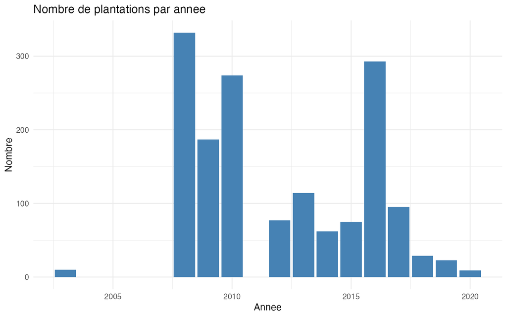

Nombre de plantations enregistrees par annee.

La grande majorite des dates de plantation n’etant pas renseignee (86% de NA), ce graphique porte sur une minorite des arbres. Il reste utile pour visualiser l’effort de plantation des dernieres annees.

# 5 Visualisation cartographique

Les données de coordonnées (système EPSG:3949) ont été converties en WGS84 pour permettre l’affichage sur des fonds de carte interactifs via le package `leaflet`.

## 5.1 Tous les arbres

La carte 1 positionne l’ensemble des **11419 arbres** géolocalisés sur le territoire de Saint-Quentin. Chaque marqueur vert indique la position d’un arbre ; le popup affiche le quartier et l’espèce.

[interactive chart not shown]

Carte interactive de l’ensemble des arbres (vert).

## 5.2 Arbres remarquables

Parmi les 11419 arbres, **110 sont classés remarquables**. Ils sont représentés en rouge sur la carte 2.

[interactive chart not shown]

Carte des arbres remarquables (rouge).

## 5.3 Densité par quartier et par secteur

Les cartes 3 et 4 agrègent les arbres par quartier et par secteur. La taille de chaque bulle est proportionnelle à la racine carrée du nombre d’arbres, ce qui permet de comparer visuellement les concentrations sans que les grandes valeurs n’écrasent les petites.

[interactive chart not shown]

Densité d’arbres par quartier (bleu).

[interactive chart not shown]

Densité d’arbres par secteur (violet).

# 6 Analyse des corrélations

## 6.1 Corrélations entre variables numériques

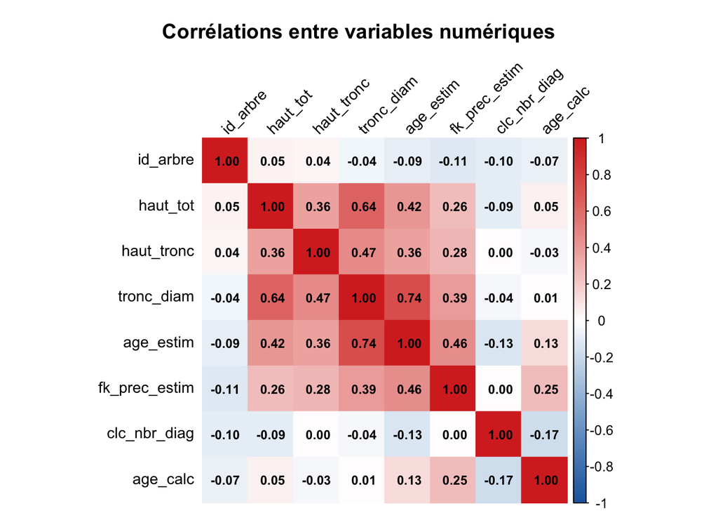

Matrice de corrélation des variables numériques.

Les corrélations les plus fortes s’observent entre `haut_tot`, `tronc_diam` et `age_estim`, ce qui est cohérent : un arbre plus âgé est en général plus grand et plus gros.

## 6.2 Arbres remarquables par quartier et état sanitaire

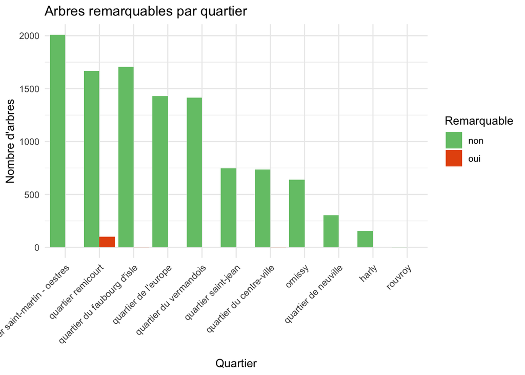

Nombre d’arbres remarquables par quartier.

Le quartier Remicourt concentre à lui seul la grande majorité des **110 arbres remarquables** recensés sur la ville.

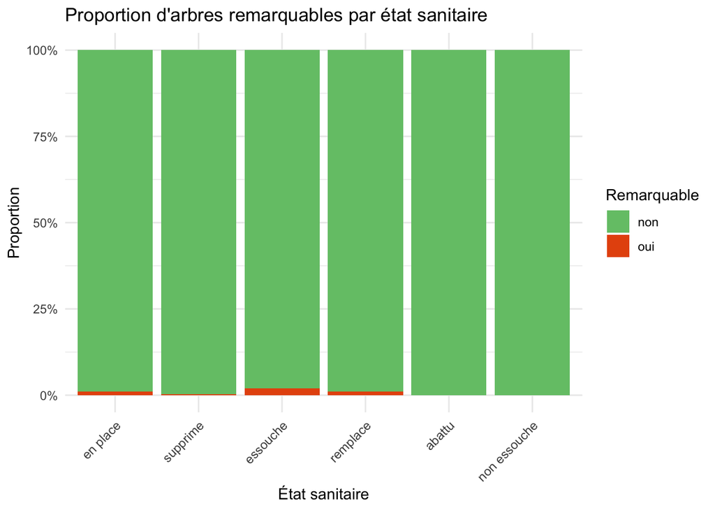

Proportion d’arbres remarquables par état sanitaire.

## 6.3 Hauteur et diamètre selon l’état sanitaire

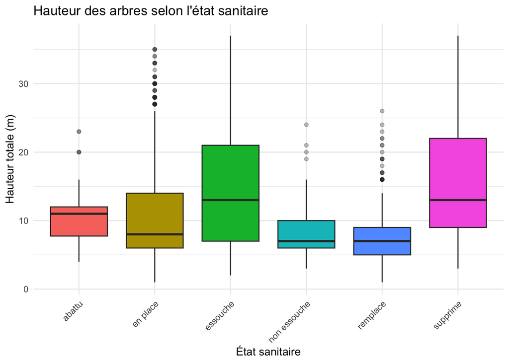

Hauteur totale selon l’état sanitaire.

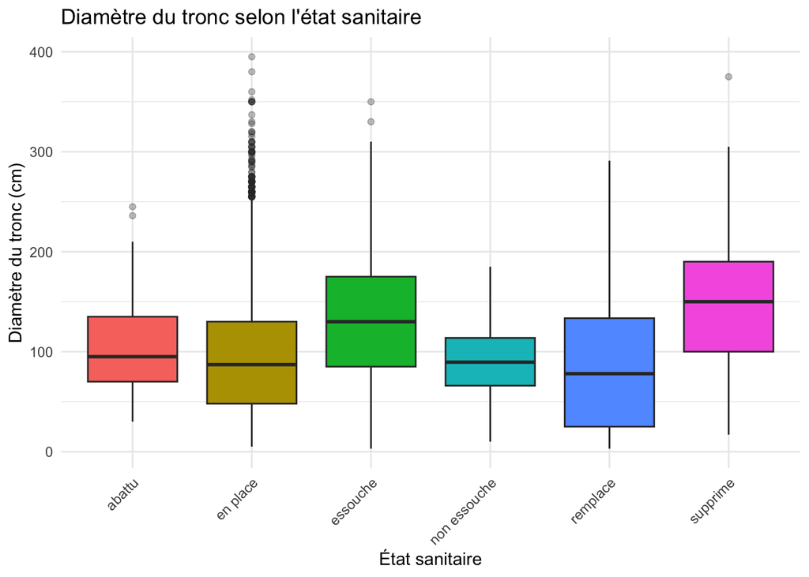

Diamètre du tronc selon l’état sanitaire.

## 6.4 Tests d’indépendance (Chi²)

# 7 Régression

## 7.1 Harmonisation des zones

Pour déterminer les zones où il faut planter des arbres afin d’harmoniser le développement global de la ville, on peut créer deux types de zones :

- **Les zones spatiales** : ce sont les zones avec le moins d’arbres, par exemple dans les quartiers suivants : HARLY, NEUVILLE, ROUVROY
- **Les zones temporelles** : ce sont les zones avec des arbres vieux, sans beaucoup d’arbres jeunes, par exemple dans les quartiers suivants : Quartier de l’Europe, Remicourt, Centre-Ville

En rajoutant des arbres dans ces zones, on pourra harmoniser le développement global de la ville.

## 7.2 Étude de la régression linéaire

Pour prédire la variable âge de l’arbre, il faut d’abord se demander quelles variables peuvent permettre de la prédire. Après analyse, ces variables seraient les meilleures pour prédire l’âge d’un arbre :

- Hauteur totale de l’arbre
- Hauteur du tronc
- Diamètre du tronc

En appliquant ces variables et en créant le modèle, on obtient les résultats suivants :

```
##
## Call:
## lm(formula = age_estim ~ haut_tot + haut_tronc + tronc_diam,
##     data = arbres)
##
## Residuals:
##     Min      1Q  Median      3Q     Max
## -59.511  -7.301  -1.881   5.332 134.472
##
## Coefficients:
##              Estimate Std. Error t value Pr(>|t|)
## (Intercept) -0.364050   0.304384  -1.196    0.232
## haut_tot    -0.022302   0.030849  -0.723    0.470
## haut_tronc   3.066973   0.093639  32.753   <2e-16 ***
## tronc_diam   0.240192   0.002997  80.142   <2e-16 ***
## ---
## Signif. codes:  0 '***' 0.001 '**' 0.01 '*' 0.05 '.' 0.1 ' ' 1
##
## Residual standard error: 12.17 on 9447 degrees of freedom
##   (1968 observations effacées parce que manquantes)
## Multiple R-squared:  0.6358, Adjusted R-squared:  0.6357
## F-statistic:  5498 on 3 and 9447 DF,  p-value: < 2.2e-16
```

## 7.3 Étude de la régression logistique

Pour savoir quels sont les arbres à abattre, il faut d’abord se demander quelles variables peuvent permettre de le déterminer. Après analyse, ces variables seraient les meilleures pour identifier les arbres à abattre :

- Hauteur totale de l’arbre
- Hauteur du tronc
- Diamètre du tronc
- L’âge estimé
- Le stade de développement

En appliquant ces variables et en créant le modèle, on obtient les résultats suivants :

```
##
## Call:
## glm(formula = a_abattre ~ haut_tot + haut_tronc + tronc_diam +
##     age_estim + fk_stadedev, family = binomial, data = arbres)
##
## Coefficients:
##                        Estimate Std. Error z value Pr(>|z|)
## (Intercept)          -4.119e+00  5.821e-01  -7.076 1.48e-12 ***
## haut_tot             -8.605e-03  3.701e-02  -0.233  0.81612
## haut_tronc           -1.114e-01  1.430e-01  -0.779  0.43590
## tronc_diam           -7.898e-05  4.689e-03  -0.017  0.98656
## age_estim            -1.470e-02  1.444e-02  -1.018  0.30864
## fk_stadedevjeune     -1.827e+00  5.749e-01  -3.177  0.00149 **
## fk_stadedevsenescent -1.191e+01  8.831e+02  -0.013  0.98924
## fk_stadedevvieux     -1.312e+01  8.094e+02  -0.016  0.98707
## ---
## Signif. codes:  0 '***' 0.001 '**' 0.01 '*' 0.05 '.' 0.1 ' ' 1
##
## (Dispersion parameter for binomial family taken to be 1)
##
##     Null deviance: 527.91  on 9448  degrees of freedom
## Residual deviance: 512.95  on 9441  degrees of freedom
## AIC: 528.95
##
## Number of Fisher Scoring iterations: 17
```

Pour aller plus loin, une matrice de confusion a été créée :

```
##       Reel
## Predit    0    1
##      0 9408   41
```

# 8 Conclusion

L’exploration a surtout montre qu’on avait affaire a une base saisie a la main : modalites ecrites differemment d’une ligne a l’autre, “RAS” au lieu de NA, des 0 qui devraient etre des NA, quelques valeurs aberrantes et des dates par defaut a 1970. Au final le nettoyage n’a supprime que 2 lignes, mais les regles appliquees rendent le fichier exploitable pour la suite.

Le fichier `data/clean/arbres_clean.csv` est celui qui sert de base pour les fonctionnalites 3 a 6 (carte, correlations, regressions).